# NYPD Shooting Data

B. Tucker

2026-04-18

## Reading in and tidying the data

First, we will read the data in.

```r
##Read in the csv file in and assign that to our data frame.

NYPD_Shootings <- read_csv("C:/Users/kuros/Downloads/ARCHIVED_NYPD_Shooting_Incident_Data__Historic_.csv")
```

Next, we’ll look at an overview of the data.

```r
## Use the glimpse function to look at column information
glimpse(NYPD_Shootings)
```

```
## Rows: 29,744
## Columns: 21
## $ INCIDENT_KEY            <dbl> 231974218, 177934247, 255028563, 25384540, 726…
## $ OCCUR_DATE              <chr> "08/09/2021", "04/07/2018", "12/02/2022", "11/…
## $ OCCUR_TIME              <time> 01:06:00, 19:48:00, 22:57:00, 01:50:00, 01:58…
## $ BORO                    <chr> "BRONX", "BROOKLYN", "BRONX", "BROOKLYN", "BRO…
## $ LOC_OF_OCCUR_DESC       <chr> NA, NA, "OUTSIDE", NA, NA, NA, NA, NA, NA, NA,…
## $ PRECINCT                <dbl> 40, 79, 47, 66, 46, 42, 71, 69, 75, 69, 40, 42…
## $ JURISDICTION_CODE       <dbl> 0, 0, 0, 0, 0, 2, 0, 2, 0, 0, 0, 2, 0, 0, 2, 0…
## $ LOC_CLASSFCTN_DESC      <chr> NA, NA, "STREET", NA, NA, NA, NA, NA, NA, NA, …
## $ LOCATION_DESC           <chr> NA, NA, "GROCERY/BODEGA", "PVT HOUSE", "MULTI …
## $ STATISTICAL_MURDER_FLAG <lgl> FALSE, TRUE, FALSE, TRUE, TRUE, FALSE, TRUE, F…
## $ PERP_AGE_GROUP          <chr> NA, "25-44", "(null)", "UNKNOWN", "25-44", "18…
## $ PERP_SEX                <chr> NA, "M", "(null)", "U", "M", "M", NA, NA, "M",…
## $ PERP_RACE               <chr> NA, "WHITE HISPANIC", "(null)", "UNKNOWN", "BL…
## $ VIC_AGE_GROUP           <chr> "18-24", "25-44", "25-44", "18-24", "<18", "18…
## $ VIC_SEX                 <chr> "M", "M", "M", "M", "F", "M", "M", "M", "M", "…
## $ VIC_RACE                <chr> "BLACK", "BLACK", "BLACK", "BLACK", "BLACK", "…
## $ X_COORD_CD              <dbl> 1006343.0, 1000082.9, 1020691.0, 985107.3, 100…
## $ Y_COORD_CD              <dbl> 234270.0, 189064.7, 257125.0, 173349.8, 247502…
## $ Latitude                <dbl> 40.80967, 40.68561, 40.87235, 40.64249, 40.845…
## $ Longitude               <dbl> -73.92019, -73.94291, -73.86823, -73.99691, -7…
## $ Lon_Lat                 <chr> "POINT (-73.92019278899994 40.80967347200004)"…
```

After reviewing the column information, we’ll mutate columns for proper object classification. We’ll also eliminate columns we don’t need, and filter out unknown or missing (NA) values.

```r
NYPD_Shootings <- NYPD_Shootings %>%
  filter(!is.na(VIC_RACE),
         !is.na(VIC_AGE_GROUP),
         VIC_RACE != "UNKNOWN",
         VIC_AGE_GROUP != "UNKNOWN",
         VIC_AGE_GROUP != "1022") %>%
  mutate(OCCUR_DATE = mdy(OCCUR_DATE),
         BORO = str_to_title(BORO),
         PERP_AGE_GROUP = factor(PERP_AGE_GROUP),
         VIC_AGE_GROUP = factor(VIC_AGE_GROUP,
                                levels = c("<18", "18-24", "25-44", "45-64", "65+")),
         PERP_RACE = factor(PERP_RACE),
         VIC_RACE = factor(VIC_RACE),
         PERP_SEX = factor(PERP_SEX),
         VIC_SEX = factor(VIC_SEX)) %>%
  select(-c(INCIDENT_KEY, `LOC_OF_OCCUR_DESC`, PRECINCT, JURISDICTION_CODE, `LOC_CLASSFCTN_DESC`, `LOCATION_DESC`,
          STATISTICAL_MURDER_FLAG, X_COORD_CD, Y_COORD_CD, Latitude, Longitude, `Lon_Lat`))

## Lets look at NYPD_Shootings now

NYPD_Shootings
```

| OCCUR_DATE | OCCUR_TIME | BORO | PERP_AGE_GROUP | PERP_SEX | PERP_RACE | VIC_AGE_GROUP | VIC_SEX | VIC_RACE |
| --- | --- | --- | --- | --- | --- | --- | --- | --- |
| 2021-08-09 | 01:06:00 | Bronx | NA | NA | NA | 18-24 | M | BLACK |
| 2018-04-07 | 19:48:00 | Brooklyn | 25-44 | M | WHITE HISPANIC | 25-44 | M | BLACK |
| 2022-12-02 | 22:57:00 | Bronx | (null) | (null) | (null) | 25-44 | M | BLACK |
| 2006-11-19 | 01:50:00 | Brooklyn | UNKNOWN | U | UNKNOWN | 18-24 | M | BLACK |
| 2010-05-09 | 01:58:00 | Bronx | 25-44 | M | BLACK | <18 | F | BLACK |
| 2012-07-22 | 21:35:00 | Bronx | 18-24 | M | BLACK | 18-24 | M | BLACK |
| 2011-07-12 | 22:26:00 | Brooklyn | NA | NA | NA | 25-44 | M | BLACK |
| 2012-07-14 | 23:45:00 | Brooklyn | NA | NA | NA | 25-44 | M | WHITE HISPANIC |
| 2015-04-21 | 15:36:00 | Brooklyn | 25-44 | M | BLACK | 25-44 | M | BLACK |
| 2016-05-07 | 15:23:00 | Brooklyn | 18-24 | M | BLACK | 18-24 | M | BLACK |

[output cut: 9990 more lines]

Now that we have transformed and cleaned our data, we can move into the analysis portion

## Analyzing and visualizing the data

To begin, lets examine victimization by age group

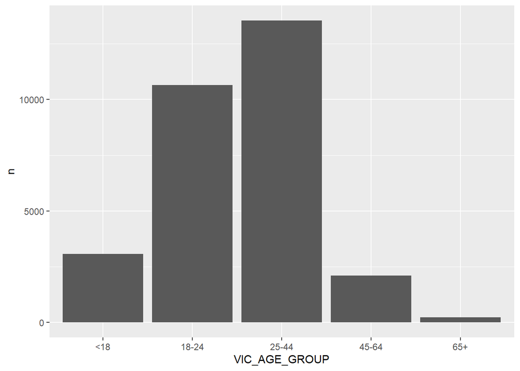

```r
NYPD_Shootings %>%
  count(VIC_AGE_GROUP) %>%
  ggplot(aes(x= VIC_AGE_GROUP, y = n))+
  geom_col()
```

Now we’ll look at victimization by race

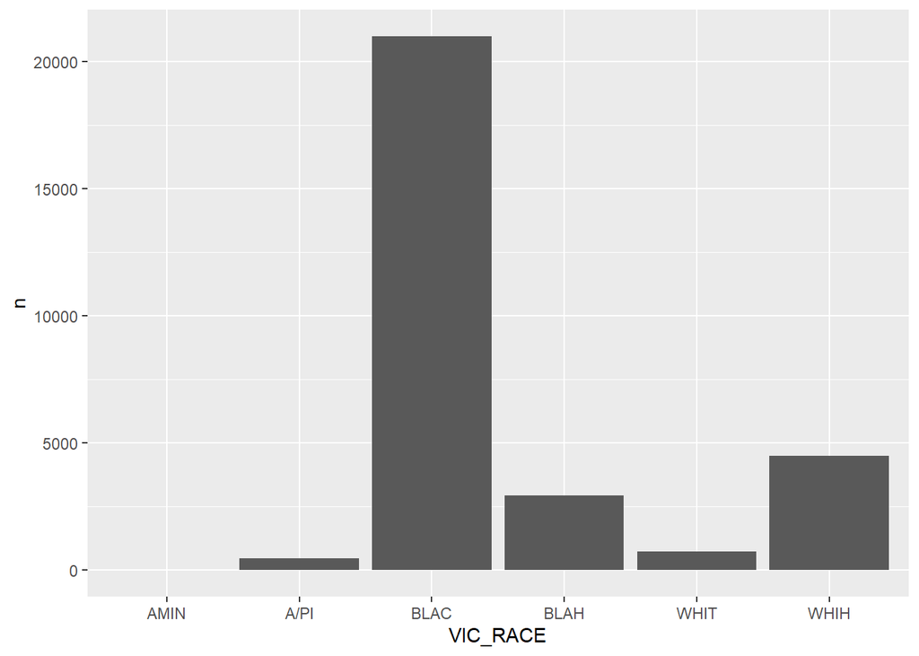

```r
NYPD_Shootings %>%
  count(VIC_RACE) %>%
  ggplot(aes(x= VIC_RACE, y = n))+
  geom_col() +
  scale_x_discrete(labels = abbreviate)
```

```r
## Utilize scale_x_discrete to abbreviate the labels on the x axis
```

Now that we’ve looked at victimization by age and by race, lets model what proportion of victims are of specific age groups across racial categories.

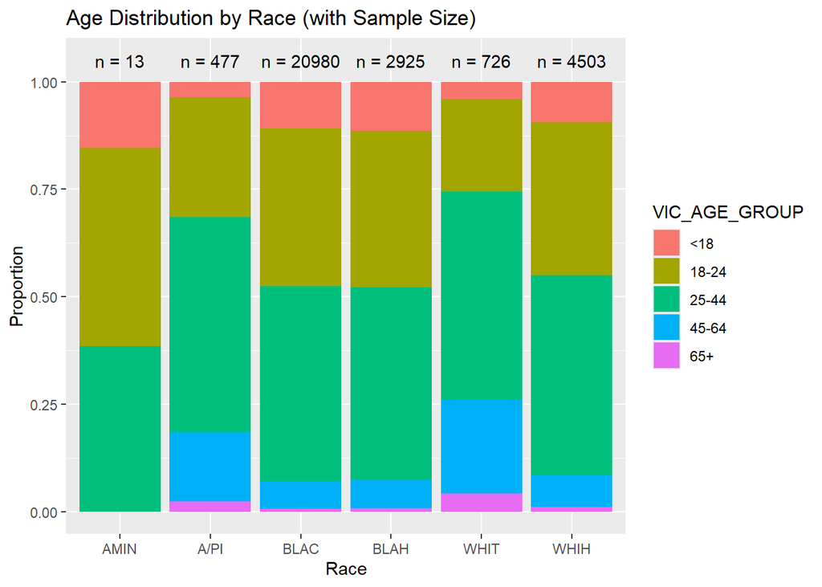

```r
counts <- NYPD_Shootings %>%
  count(VIC_RACE)

ggplot(NYPD_Shootings, aes(x = VIC_RACE, fill = VIC_AGE_GROUP)) +
  geom_bar(position = "fill") +
  geom_text(
    data = counts,
    aes(x = VIC_RACE, y = 1.05, label = paste0("n = ", n)),
    inherit.aes = FALSE
  ) +
  labs(
    title = "Age Distribution by Race (with Sample Size)",
    x = "Race",
    y = "Proportion"
  ) +
  scale_x_discrete(labels = abbreviate)
```

This visual allows us to see the proportion of victim age groups by racial category. We include the category n size to provide some context.

While the visualization may appear to indicate notable stratification for specific age group distributions and specific races, lets look at whether there’s an association between victim race and victim age group.

```r
## We'll run a chi-square test to check, and also use a Cramer's V test to look at effect size.

chi_square_data <- table(NYPD_Shootings$VIC_RACE,
                         NYPD_Shootings$VIC_AGE_GROUP)

chisq.test(chi_square_data)
```

```
##
##  Pearson's Chi-squared test
##
## data:  chi_square_data
## X-squared = 546.75, df = 20, p-value < 2.2e-16
```

When we run this data, we see there’s a very small p-value, indicating a statistically significant association between victim race and age group. Lets now review the proportions of that data to see how victims are actually distributed across age groups

```r
## To avoid proportions printing in scientific notation, multiply by 100 to create a readable decimal.

prop.table(chi_square_data, 1) * 100
```

```
##
##                                         <18      18-24      25-44      45-64
##   AMERICAN INDIAN/ALASKAN NATIVE 15.3846154 46.1538462 38.4615385  0.0000000
##   ASIAN / PACIFIC ISLANDER        3.5639413 27.8825996 50.1048218 16.1425577
##   BLACK                          10.8198284 36.6730219 45.5004766  6.4013346
##   BLACK HISPANIC                 11.4188034 36.4102564 44.7521368  6.6666667
##   WHITE                           3.9944904 21.4876033 48.3471074 22.0385675
##   WHITE HISPANIC                  9.4381523 35.5984899 46.4579169  7.4838996
##
##                                         65+
##   AMERICAN INDIAN/ALASKAN NATIVE  0.0000000
##   ASIAN / PACIFIC ISLANDER        2.3060797
##   BLACK                           0.6053384
##   BLACK HISPANIC                  0.7521368
##   WHITE                           4.1322314
##   WHITE HISPANIC                  1.0215412
```

We could stop here, but we’d be remiss to not examine effect size, which will suggest to us how significant these statistical findings may actually be.

```r
cramer_v <- cramerV(chi_square_data)

cramer_v
```

```
## Cramer V
##  0.06793
```

## Conclusion & Bias

After performing all our analysis, we get a clearer picture of what is happening, and an answer to our question.

We do have to consider that we removed unknown values, and this may have an impact on the results. This choice introduces bias, because we are only focusing on values we have data for. But this doesn’t eliminate that a victim whose information was unknown existed. There is also some natural bias in the choice to use this dataset, which focuses on crime in New York City, and reporting on crime in this city has historically seen unequal reporting by both police and the public.